# STA232Lab8

Po

3/2/2020

# HW 5

Q1. Equation (5) in lecture note 2.

Q2. “$y$’s are indpendent copies repected $K$ times” means you just factorize the likelihood as if those repeated $y$’s are independnet.

## GLMM

Finite Mixture Models for Proportions  
S. P. Brooks, B. J. T. Morgan, M. S. Ridout and S. E. Pack  
Biometrics Vol. 53, No. 3 (Sep., 1997), pp. 1097-1115 (19 pages)  
https://www.jstor.org/stable/2533567?seq=1#page_scan_tab_contents

Robust estimation in generalised linear mixed models  
Jiming Jiang Weihong Zhang  
Biometrika, Volume 88, Issue 3, 1 October 2001, Pages 753–765  
https://academic.oup.com/biomet/article/88/3/753/340112

The data set is fitted by generalized linear mixed model with Bernoulli response $y_{ij}$, $i = 1, \dots, 1328$, $j = 1, \dots, n_i$, where $n_i$ is the size of the $i$ th litter;

$y_{ij} = 1$ if the $j$ th implant in the $i$ th litter is dead, and $y_{ij} = 0$ otherwise.

The total number of responses is $N = \sum_{i = 1}^{1328} n_i = 10533$.

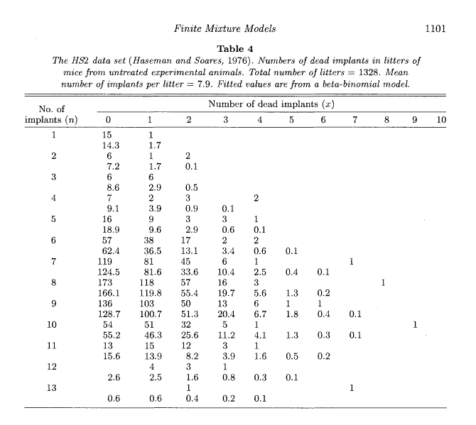

```r
print(head(mice, 20))
```

```
##    Nimplants Ndead litter
## 1          4     0      1
## 2          4     0      2
## 3          4     0      3
## 4          4     0      4
## 5          4     0      5
## 6          4     0      6
## 7          4     0      7
## 8          4     1      8
## 9          4     1      9
## 10         4     2     10
## 11         4     2     11
## 12         4     2     12
## 13         4     4     13
## 14         4     4     14
## 15         5     0     15
## 16         5     0     16
## 17         5     0     17
## 18         5     0     18
## 19         5     0     19
## 20         5     0     20
```

The link function is logit. The linear predictor is $\eta_{ij} = \mu + \alpha_i$, where $\alpha_1 , \dots, \alpha_m$ are random effects independent and distributed as $N (0, \sigma^2)$, and $\sigma$ and $\mu$ are unknown parameters.

The exponential family is Bernoulli distribution, with $P(y_{ij} = 1 | \alpha) = p_{ij}$. Therefore we have $y_{ij}$ conditionally independent such that
$$\text{logit} \{ P(y_{ij} = 1 | \alpha) \} = \mu + \alpha_i .$$

Find $\sigma$ and $\mu$ such that $\log f(y, \alpha| \mu, \sigma)$ is maximized.

```r
m1 <- glmer(cbind(Ndead, Nimplants-Ndead) ~ 1 + (1|litter), family = binomial, data = mice)
summary(m1)
```

```
## Generalized linear mixed model fit by maximum likelihood (Laplace
##   Approximation) [glmerMod]
##  Family: binomial  ( logit )
## Formula: cbind(Ndead, Nimplants - Ndead) ~ 1 + (1 | litter)
##    Data: mice
##
##      AIC      BIC   logLik deviance df.resid
##    128.3    131.9    -62.1    124.3       44
##
## Scaled residuals:
##     Min      1Q  Median      3Q     Max
## -0.5651 -0.5651 -0.1770  0.3936  1.2470
##
## Random effects:
##  Groups Name        Variance Std.Dev.
##  litter (Intercept) 2.603    1.613
## Number of obs: 46, groups:  litter, 46
##
## Fixed effects:
##             Estimate Std. Error z value Pr(>|z|)
## (Intercept)  -1.9695     0.3956  -4.979 6.39e-07 ***
## ---
## Signif. codes:  0 '***' 0.001 '**' 0.01 '*' 0.05 '.' 0.1 ' ' 1
```

```r
library(rstanarm)
m2 <- stan_glmer(cbind(Ndead, Nimplants-Ndead) ~ 1 + (1|litter), family = binomial, data = mice, refresh=0)
m2
```

```
## stan_glmer
##  family:       binomial [logit]
##  formula:      cbind(Ndead, Nimplants - Ndead) ~ 1 + (1 | litter)
##  observations: 46
## ------
##             Median MAD_SD
## (Intercept) -1.9    0.4
##
## Error terms:
##  Groups Name        Std.Dev.
##  litter (Intercept) 1.8
## Num. levels: litter 46
##
## ------
## * For help interpreting the printed output see ?print.stanreg
## * For info on the priors used see ?prior_summary.stanreg
```

# MCEM

#### Goal

Find $\text{argmax}_\theta f(y|\theta)$ where $f(y| \theta) = \int f(y, \alpha| \theta) d\alpha$

Instead, find $\text{argmax}_\theta E_{\alpha | y} [f(y, \alpha|\theta)]$

#### EM algorithm

- E-Step  
  Construct the function $Q(\theta|\theta^{(k)}) := \text{E}( \log f(y, \alpha| \theta) | y, \theta^{(k)}) \approx \frac{1}{L}\sum_l \log f(y, \alpha_\text{MC}^{(l)} | \theta)$  
  where $\alpha_\text{MC}^{(l)}$’s are MCMC samples of $\alpha|y, \theta^{(k)}$

  Use MCMC algorithm such as Metropolis-Hastings. In general we can use NUTS https://mc-stan.org/users/interfaces/rstan.
- M-Step  
  $\theta^{(k+1)} = \text{argmax}_\theta Q(\theta|\theta^{(k)})$

  Use `optim` in R.

#### Metropolis-Hastings algorithm

Draw MCMC samples of $\alpha|y, \theta^{(k)}$.

https://en.wikipedia.org/wiki/Metropolis%E2%80%93Hastings_algorithm

Burin-in: Use the stationary sequence

Thining: Independent samples

#### Standard error estimation

standard errors of the MLEs – asymptotic covariance matrix – Fisher information matrix

Compute the observed Fisher information matrix for MCEM.

> Gelman, Andrew, and Xiao-Li Meng, eds. Applied Bayesian modeling and causal inference from incomplete-data perspectives. John Wiley & Sons, 2004. Page 256 equation (23.6)

```r
library(tidyverse)
library(lme4)
lamb <- read.csv(file = "lamb.csv") %>%
        mutate(Sire = factor(Sire),
               Line = factor(Line),
               Age  = factor(Age)
        )
lamb_reml <- lmer(Weight ~ 1 + (1|Sire), data = lamb)
y = getME(lamb_reml, "y")
X = getME(lamb_reml, "X")
Z = getME(lamb_reml, "Z")
r = 10

E_step <- function(theta, y, X, Z, r) {
  n = dim(Z)[1]
  k = dim(Z)[2]
  beta      <- theta$beta
  tau_sq    <- theta$tau_sq
  sigma_sq  <- theta$sigma_sq

  alpha_given_data = replicate(r, {
                          solve(t(Z)%*%Z/tau_sq + diag(k)/sigma_sq,
                                t(Z)%*%(y - X%*%beta + sqrt(tau_sq)*rnorm(n))/tau_sq
                          ) +sqrt(1/sigma_sq)*rnorm(k)
                     })
  fr = function(x) {
    mean(sapply(alpha_given_data, function(alpha) {
      sum((y - (X * x[1] * 2 + Z %*% alpha))^2) / x[2] + n*log(x[2]) + sum(alpha^2) / x[3] + k*log(x[3])
    }))
  }
  return(fr)
}

M_step <- function(fr, theta) {
  out = optim(c(theta$beta[1]/2, theta$tau_sq, theta$sigma_sq), fr,
              lower = 1e-10, upper = 20, method = "L-BFGS-B")
  return(list(beta=array(2*out$par[1], 1), tau_sq=out$par[2], sigma_sq=out$par[3], val = out$val))
}

# Initialization
theta = list(beta=array(mean(lamb$Weight), 1), tau_sq=sd(lamb$Weight)^2*0.5, sigma_sq=sd(lamb$Weight)^2*0.5)
for(i in 1:6){
  if(i==1) print(c("obj.", "beta", "tau_sq", "sigma_sq"))
  # E step
  qfun <- E_step(theta, y, X, Z, r+2*i)
  # M step
  theta <- M_step(qfun, theta)
  # Print result
  print(c(theta$val, theta$beta[1], theta$tau_sq, theta$sigma_sq))
}
```

```
## [1] "obj."     "beta"     "tau_sq"   "sigma_sq"
## [1] 163.451746  10.911046   2.759904   1.962667
## [1] 165.816516  10.843879   2.896394   1.909855
## [1] 161.726249  10.994761   2.985995   1.472350
## [1] 166.048147  11.021051   3.078269   1.637107
## [1] 164.304748  10.905941   3.053827   1.550531
## [1] 166.126791  10.892681   3.159565   1.531245
```

```r
summary(lamb_reml)
```

```
## Linear mixed model fit by REML ['lmerMod']
## Formula: Weight ~ 1 + (1 | Sire)
##    Data: lamb
##
## REML criterion at convergence: 250.6
##
## Scaled residuals:
##      Min       1Q   Median       3Q      Max
## -2.59653 -0.62476  0.08731  0.63045  2.26973
##
## Random effects:
##  Groups   Name        Variance Std.Dev.
##  Sire     (Intercept) 0.4349   0.6595
##  Residual             2.9783   1.7258
## Number of obs: 62, groups:  Sire, 23
##
## Fixed effects:
##             Estimate Std. Error t value
## (Intercept)  10.9596     0.2717   40.34
```